# Practical Machine Learning Final Project

Jonathan Zax

April 29, 2016

## Executive Summary

This project in Practical Machine Learning will examine a dataset prepared for the paper *Qualitative Activity Recognition of Weight Lifting Exercises* by Velloso, E.; Bulling, A.; Gellersen, H.; Ugulino, W.; Fuks, H. in order to model the exercise technique (*classe* variable) used by study participants based upon an extensive series of accelerometer measurements and predict the *classe* for a small test set of measurements.

## Introduction

This project makes use of the Weight Lifting Exercise Dataset documented [here](http://groupware.les.inf.puc-rio.br/har), and available for download [here](http://groupware.les.inf.puc-rio.br/static/WLE/WearableComputing_weight_lifting_exercises_biceps_curl_variations.csv).

The data was collected using 4 on-body accelerometers with each of 6 participants, performing sets of the Unilateral Dumbbell Biceps Curl with 5 different techniques - 1 correct, and the remainder displaying idiosyncratic errors.

The project intends to use data from accelerometers on the belt, forearm, arm, and dumbell to predict the manner in which participants performed the exercise. The prediction model will then be used to predict 20 different test cases.

```r
## Read in the training and testing data files from the local working directory
testing = read.csv("~/pml-testing.csv")
training = read.csv("~/pml-training.csv")
```

The training dataset is comprised of 19622 observations, each with 160 variables.

A number of libraries will be required for the model and are loaded now:

```r
library(lattice)
library(ggplot2)
library(caret)
library(gbm)
library(randomForest)
```

## Data Processing

A random look at several variables reveals that there are identification and time fields that may not be relevant to the model, as well as a substantial presence of *NA* values and other variable characteristics that might benefit from some further data selection.

```r
summary(training[,c(5,20,25,37,69,87,103,141,158)])
```

```
##           cvtd_timestamp   max_yaw_belt   amplitude_pitch_belt
##  28/11/2011 14:14: 1498          :19216   Min.   : 0.000
##  05/12/2011 11:24: 1497   -1.1   :   30   1st Qu.: 1.000
##  30/11/2011 17:11: 1440   -1.4   :   29   Median : 1.000
##  05/12/2011 11:25: 1425   -1.2   :   26   Mean   : 2.167
##  02/12/2011 14:57: 1380   -0.9   :   24   3rd Qu.: 2.000
##  02/12/2011 13:34: 1375   -1.3   :   22   Max.   :12.000
##  (Other)         :11007   (Other):  275   NA's   :19216
##   gyros_belt_x       kurtosis_roll_arm kurtosis_roll_dumbbell
##  Min.   :-1.040000           :19216           :19216
##  1st Qu.:-0.030000   #DIV/0! :   78    #DIV/0!:    5
##  Median : 0.030000   -0.02438:    1    -0.2583:    2
##  Mean   :-0.005592   -0.04190:    1    -0.3705:    2
##  3rd Qu.: 0.110000   -0.05051:    1    -0.5855:    2
##  Max.   : 2.220000   -0.05695:    1    -2.0851:    2
##                      (Other) :  324    (Other):  393
##  var_accel_dumbbell var_accel_forearm magnet_forearm_y
##  Min.   :  0.000    Min.   :  0.000   Min.   :-896.0
##  1st Qu.:  0.378    1st Qu.:  6.759   1st Qu.:   2.0
##  Median :  1.000    Median : 21.165   Median : 591.0
##  Mean   :  4.388    Mean   : 33.502   Mean   : 380.1
##  3rd Qu.:  3.434    3rd Qu.: 51.240   3rd Qu.: 737.0
##  Max.   :230.428    Max.   :172.606   Max.   :1480.0
##  NA's   :19216      NA's   :19216
```

The training and testing subsets are prepared from the original training data:

```r
## Set the seed for reproducability
set.seed(121199)

## Create training and testing datasets from the training database
inTrain = createDataPartition(training$classe, p=0.6, list = FALSE)
train1 <- training[inTrain,]
test1 <- training[-inTrain,]
```

The new training dataset, *train1*, is then refined to reduce the number of variables evaluated for the predictive models.

```r
## Clean the data
## First removing the subject ID, time stamps and other initial record identifiers
train1 <- train1[,-c(1:7)]

## Identify and remove the variables with near-zero variance
firstCut <- nzv(train1)
train2 <- train1[,-firstCut]

## Identify and remove the variables with greater than 75% NA values
secondCut <- apply(train2, 2, function(x) sum(is.na(x)/length(x))<0.75)
train3 <- train2[,secondCut]

## Identify and remove highly correlated predictors (more than 90%), excluding the classe variable
train3cor <- cor(train3[,-ncol(train3)])
train3hc <- findCorrelation(train3cor, cutoff = .9)
train3filt <- train3[,-train3hc]

## Re-check that the new distribution has no highly correlated variables as expected
train3cor2 <- cor(train3filt[,-ncol(train3filt)])
summary(train3cor2[upper.tri(train3cor2)])
```

```
##      Min.   1st Qu.    Median      Mean   3rd Qu.      Max.
## -0.888100 -0.117700  0.001785  0.002205  0.100000  0.886300
```

The processed training dataset has now been reduced to 46 variables.

## Model Building

### Generalized Boosted Regression Model

I first want to evaluate the performance of a Generalized Boosted Regression Model on this data set, using the default arguments.

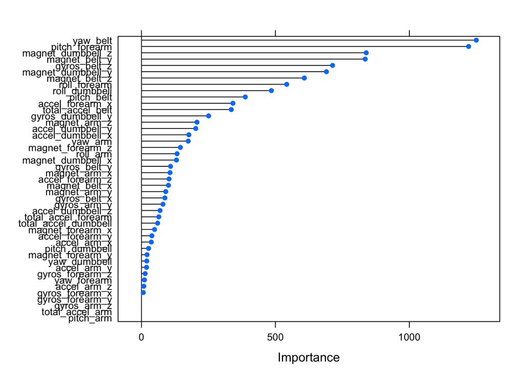

```r
## Run a first model using caret with the GBM method
modGBM <- train(classe~., data = train3filt, method="gbm", verbose = FALSE)

## Estimate and plot the variable importance
importGBM <- varImp(modGBM, scale=FALSE)
plot(importGBM)
```

Running the GBM model on the *test1* dataset resuts in the following out-of-sample errors:

```r
## Run the model on the test data
predGBM <- predict(modGBM, newdata=test1)

## Prepare a confusion matrix to get estimate of out-of-sample error
confusionMatrix(test1$classe, predGBM)
```

```
## Confusion Matrix and Statistics
##
##           Reference
## Prediction    A    B    C    D    E
##          A 2201   22    7    2    0
##          B   50 1419   42    0    7
##          C    0   41 1302   21    4
##          D    1    2   52 1214   17
##          E    1   12   16   18 1395
##
## Overall Statistics
##
##                Accuracy : 0.9599
##                  95% CI : (0.9553, 0.9641)
##     No Information Rate : 0.2872
##     P-Value [Acc > NIR] : < 2.2e-16
##
##                   Kappa : 0.9492
##  Mcnemar's Test P-Value : 5.091e-06
##
## Statistics by Class:
##
##                      Class: A Class: B Class: C Class: D Class: E
## Sensitivity            0.9769   0.9485   0.9175   0.9673   0.9803
## Specificity            0.9945   0.9844   0.9897   0.9891   0.9927
## Pos Pred Value         0.9861   0.9348   0.9518   0.9440   0.9674
## Neg Pred Value         0.9907   0.9878   0.9819   0.9937   0.9956
## Prevalence             0.2872   0.1907   0.1809   0.1600   0.1814
## Detection Rate         0.2805   0.1809   0.1659   0.1547   0.1778
## Detection Prevalence   0.2845   0.1935   0.1744   0.1639   0.1838
## Balanced Accuracy      0.9857   0.9665   0.9536   0.9782   0.9865
```

The GBM method results in an accuracy rate of 96% using the testing data.

### Random Forest Model

I would like to explore the use of a Random Forest model as well, to see if the accuracy can be improved.

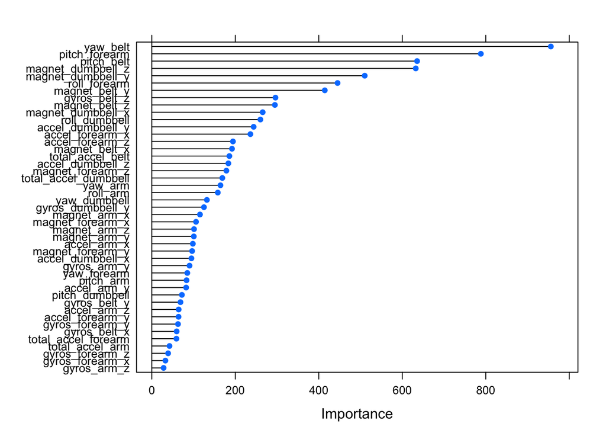

```r
## Create an initial RF model
modRF <- train(classe~., data = train3filt, method="rf")

## Estimate and plot the variable importance
importRF <- varImp(modRF, scale = FALSE)
plot(importRF)
```

```r
modRF$finalModel
```

```
##
## Call:
##  randomForest(x = x, y = y, mtry = param$mtry)
##                Type of random forest: classification
##                      Number of trees: 500
## No. of variables tried at each split: 23
##
##         OOB estimate of  error rate: 0.77%
## Confusion matrix:
##      A    B    C    D    E  class.error
## A 3346    1    0    0    1 0.0005973716
## B   20 2250    6    1    2 0.0127248793
## C    0   12 2034    8    0 0.0097370983
## D    0    1   24 1903    2 0.0139896373
## E    0    0    4    9 2152 0.0060046189
```

```r
modRF$results
```

```
##   mtry  Accuracy     Kappa  AccuracySD     KappaSD
## 1    2 0.9845059 0.9804001 0.002411599 0.003050473
## 2   23 0.9875373 0.9842357 0.002446384 0.003097416
## 3   45 0.9776574 0.9717403 0.006711811 0.008485810
```

Although it took quite a long time, the Random Forest model on the *test1* dataset results in better accuracy and fewer out-of-sample errors.

### Cross Validation

The Random Forest Model can now be cross-validated on the withheld *test1* dataset, prior to its application to the final *testing* data.

```r
## Run a prediction from the RF model
predRF <- predict(modRF, newdata=test1)
confusionMatrix(test1$classe, predRF)
```

```
## Confusion Matrix and Statistics
##
##           Reference
## Prediction    A    B    C    D    E
##          A 2230    2    0    0    0
##          B   17 1493    8    0    0
##          C    0   10 1353    5    0
##          D    0    0   16 1270    0
##          E    0    0    0    5 1437
##
## Overall Statistics
##
##                Accuracy : 0.992
##                  95% CI : (0.9897, 0.9938)
##     No Information Rate : 0.2864
##     P-Value [Acc > NIR] : < 2.2e-16
##
##                   Kappa : 0.9898
##  Mcnemar's Test P-Value : NA
##
## Statistics by Class:
##
##                      Class: A Class: B Class: C Class: D Class: E
## Sensitivity            0.9924   0.9920   0.9826   0.9922   1.0000
## Specificity            0.9996   0.9961   0.9977   0.9976   0.9992
## Pos Pred Value         0.9991   0.9835   0.9890   0.9876   0.9965
## Neg Pred Value         0.9970   0.9981   0.9963   0.9985   1.0000
## Prevalence             0.2864   0.1918   0.1755   0.1631   0.1832
## Detection Rate         0.2842   0.1903   0.1724   0.1619   0.1832
## Detection Prevalence   0.2845   0.1935   0.1744   0.1639   0.1838
## Balanced Accuracy      0.9960   0.9940   0.9901   0.9949   0.9996
```

The RF method results in an accuracy rate of 99.2% using the testing data.

```r
oosErr <- sum(predRF != test1$classe)/length(test1$classe)
```

The out-of-sample error rate of 0.008 is within expectations for this model. With this level of accuracy, I’m prepared to run the original 20-observation *testing* set in order to predict the respective movement classe.

## Fimal Prediction

```r
predtest <- predict(modRF, newdata = testing)
predtest
```

```
##  [1] B A B A A E D B A A B C B A E E A B B B
## Levels: A B C D E
```